# ACS County Migration Flows 2019-2020

Malia Cortez

2024-01-31

Migration, race, and total population data from ACS via the `tidycensus` package. Median house value data from from NHGIS IPUMS.

## Tidycensus

```r
v20 <- load_variables(2020, "acs5", cache = TRUE)

View(v20)
```

## Load in Data

```r
# all data from ACS. Data analyzed is from 2019
# try to load in demographics at some point with "breakdown"
acs_county_flows.2019 <- get_flows(geography = "county",
                           state="WA",
                           year = 2019,
                           geometry = TRUE)

acs_county_flows.2020 <- get_flows(geography = "county",
                           state="WA",
                           year = 2020,
                           geometry = TRUE)

# load in county population data
dat <- read.csv("data/county_pops.csv")

# gut checking
head(acs_county_flows.2019)
```

```
## Simple feature collection with 6 features and 7 fields
## Active geometry column: centroid1
## Geometry type: POINT
## Dimension:     XY
## Bounding box:  xmin: -118.5605 ymin: 46.98338 xmax: -118.5605 ymax: 46.98338
## Geodetic CRS:  NAD83
## # A tibble: 6 × 9
##   GEOID1 GEOID2 FULL1_NAME               FULL2_NAME      variable estimate   moe
##   <chr>  <chr>  <chr>                    <chr>           <chr>       <dbl> <dbl>
## 1 53001  <NA>   Adams County, Washington Central America MOVEDIN       339   217
## 2 53001  <NA>   Adams County, Washington Central America MOVEDOUT       NA    NA
## 3 53001  <NA>   Adams County, Washington Central America MOVEDNET       NA    NA
## 4 53001  <NA>   Adams County, Washington Europe          MOVEDIN         8    11
## 5 53001  <NA>   Adams County, Washington Europe          MOVEDOUT       NA    NA
## 6 53001  <NA>   Adams County, Washington Europe          MOVEDNET       NA    NA
## # ℹ 2 more variables: centroid1 <POINT [°]>, centroid2 <POINT [°]>
```

```r
# load in county characteristics
## AKSME001: total
## AKSME002: White alone
## AKSME003: Black or African American alone
## AKSME004: American Indian and Alaska Native alone
## AKSME005: Asian alone
## AKSME006: Native Hawaiian and Other Pacific Islander alone
## AKSME007: Some other race alone
## AKSME008: Two or more races
## AKSME009: Two or more races: Two races including Some other race
## AKSME010: Two or more races: Two races excluding Some other race, and three or more races
acs_char_2019 <- read.csv("data/nhgis_sex_race.csv")
```

## Data Wrangling

```r
# select name and population
county_pops_2019 <- dat %>%
  select(c(NAME_M, AKSLE001))

# narrow to just king county
kc_flows_2019 <- acs_county_flows.2019 %>%
  filter(FULL1_NAME == "King County, Washington") %>%
  select(c(FULL1_NAME, FULL2_NAME, variable, estimate))

head(kc_flows_2019)
```

```
## Simple feature collection with 6 features and 4 fields
## Geometry type: POINT
## Dimension:     XY
## Bounding box:  xmin: -121.8358 ymin: 47.49084 xmax: -121.8358 ymax: 47.49084
## Geodetic CRS:  NAD83
## # A tibble: 6 × 5
##   FULL1_NAME              FULL2_NAME variable estimate            centroid1
##   <chr>                   <chr>      <chr>       <dbl>          <POINT [°]>
## 1 King County, Washington Africa     MOVEDIN      2081 (-121.8358 47.49084)
## 2 King County, Washington Africa     MOVEDOUT       NA (-121.8358 47.49084)
## 3 King County, Washington Africa     MOVEDNET       NA (-121.8358 47.49084)
## 4 King County, Washington Asia       MOVEDIN     19672 (-121.8358 47.49084)
## 5 King County, Washington Asia       MOVEDOUT       NA (-121.8358 47.49084)
## 6 King County, Washington Asia       MOVEDNET       NA (-121.8358 47.49084)
```

```r
# filter for just "MOVEDOUT"
kc_movers_2019 <- kc_flows_2019 %>%
  filter(variable=="MOVEDOUT")

# filter for county characteristics

head(kc_movers_2019)
```

```
## Simple feature collection with 6 features and 4 fields
## Geometry type: POINT
## Dimension:     XY
## Bounding box:  xmin: -121.8358 ymin: 47.49084 xmax: -121.8358 ymax: 47.49084
## Geodetic CRS:  NAD83
## # A tibble: 6 × 5
##   FULL1_NAME              FULL2_NAME variable estimate            centroid1
##   <chr>                   <chr>      <chr>       <dbl>          <POINT [°]>
## 1 King County, Washington Africa     MOVEDOUT       NA (-121.8358 47.49084)
## 2 King County, Washington Asia       MOVEDOUT       NA (-121.8358 47.49084)
## 3 King County, Washington Central A… MOVEDOUT       NA (-121.8358 47.49084)
## 4 King County, Washington Caribbean  MOVEDOUT       NA (-121.8358 47.49084)
## 5 King County, Washington Europe     MOVEDOUT       NA (-121.8358 47.49084)
## 6 King County, Washington U.S. Isla… MOVEDOUT       NA (-121.8358 47.49084)
```

```r
## AKSME001: total
## AKSME002: White alone
## AKSME003: Black or African American alone
## AKSME004: American Indian and Alaska Native alone
## AKSME005: Asian alone
## AKSME006: Native Hawaiian and Other Pacific Islander alone
## AKSME007: Some other race alone
## AKSME008: Two or more races
## AKSME009: Two or more races: Two races including Some other race
## AKSME010: Two or more races: Two races excluding Some other race, and three or more races

county_race <- acs_char_2019 %>%
  select(c(NAME_E, AKSME001, AKSME002, AKSME003, AKSME004, AKSME005, AKSME006, AKSME007, AKSME008, AKSME009, AKSME010))

# rename columns
setnames(county_race, old=c("NAME_E", "AKSME001", "AKSME002", "AKSME003", "AKSME004", "AKSME005", "AKSME006", "AKSME007", "AKSME008", "AKSME009", "AKSME010"), new=c("county_name", "total", "white_alone", "black_alone", "amer_ind_ak_alone", "asian_alone", "nat_haw_pac_alone", "other_alone", "two_plus_alone", "two_some_other", "two_ex_some_three_plus"))

head(county_race)
```

```
##               county_name  total white_alone black_alone amer_ind_ak_alone
## 1 Baldwin County, Alabama 223234      190912       18338              2428
## 2 Calhoun County, Alabama 113605       82323       25226               201
## 3 Cullman County, Alabama     NA          NA          NA                NA
## 4  DeKalb County, Alabama  71513       59305         688               792
## 5  Elmore County, Alabama  81209       61634       17768               204
## 6  Etowah County, Alabama 102268       79988       16040               290
##   asian_alone nat_haw_pac_alone other_alone two_plus_alone two_some_other
## 1        2160                 0        4685           4711              0
## 2         225                85        3186           2359              0
## 3          NA                NA          NA             NA             NA
## 4          17               339        8327           2045              8
## 5         884                 0         216            503             64
## 6         796                12        3207           1935            142
##   two_ex_some_three_plus
## 1                   4711
## 2                   2359
## 3                     NA
## 4                   2037
## 5                    439
## 6                   1793
```

```r
# join movers with county data
# outer join
county_moves <- merge(kc_movers_2019, county_pops_2019, by.x="FULL2_NAME", by.y = "NAME_M", all.y=TRUE) %>%
  select(-(variable))

county_moves$FULL1_NAME <- "King County, Washington"

# rename variables
names(county_moves)[names(county_moves) == 'AKSLE001'] <- 'tot_pop'
names(county_moves)[names(county_moves) == 'estimate'] <- 'movers'
names(county_moves)[names(county_moves) == 'FULL2_NAME'] <- 'county2'
names(county_moves)[names(county_moves) == 'FULL1_NAME'] <- 'county1'
```

### Blank Cells

For county-to-county migration data, estimates may be blank because:

1. Estimate is out of scope (world regions)
2. Estimate DNE - an example would be movers to a different county in same state for Washington, DC (likely doesn’t apply for King County)
3. Supplemental statistics for county of residence one year ago or MCD of residence one year ago suppressed due to disclosure avoidance

**Flows with no records in the database and suppressed flows crossed by characteristics are not included in the files. The flows with no records are considered zero count estimates.**

I only included other US regions in this analysis. Further, I did a right join, with the right database being all US counties. For these reasons, I am assuming it is reasonable to just put “0” for blank estimates.

```r
# replace NAs in dataset with 0
county_moves[is.na(county_moves)] <- 0
```

```r
# make sure to remove the row with "King County" as county2
head(county_moves)
```

```
## Simple feature collection with 6 features and 4 fields (with 2 geometries empty)
## Geometry type: GEOMETRY
## Dimension:     XY
## Bounding box:  xmin: -121.8358 ymin: 47.49084 xmax: -121.8358 ymax: 47.49084
## Geodetic CRS:  NAD83
##                              county2                 county1 movers tot_pop
## 1     Do\xf1a Ana County, New Mexico King County, Washington      0  218195
## 2 Mayag\xfcez Municipio, Puerto Rico King County, Washington      0   71530
## 3                  Ada County, Idaho King County, Washington    335  481587
## 4             Adams County, Colorado King County, Washington     19  517421
## 5             Adams County, Illinois King County, Washington     18   65435
## 6         Adams County, Pennsylvania King County, Washington      0  103009
##                     geometry
## 1   GEOMETRYCOLLECTION EMPTY
## 2   GEOMETRYCOLLECTION EMPTY
## 3 POINT (-121.8358 47.49084)
## 4 POINT (-121.8358 47.49084)
## 5 POINT (-121.8358 47.49084)
## 6 POINT (-121.8358 47.49084)
```

```r
# calculate pct county characteristics
```

## EDA/More Wrangling…

```r
# how many NAs in movers?
# plot movers
unique(county_moves$county2)
```

```
##   [1] "Do\xf1a Ana County, New Mexico"
##   [2] "Mayag\xfcez Municipio, Puerto Rico"
##   [3] "Ada County, Idaho"
##   [4] "Adams County, Colorado"
##   [5] "Adams County, Illinois"
##   [6] "Adams County, Pennsylvania"
##   [7] "Aiken County, South Carolina"
##   [8] "Bayam\xf3n Municipio, Puerto Rico"
##   [9] "Alachua County, Florida"
##  [10] "Alamance County, North Carolina"
##  [11] "Alameda County, California"
##  [12] "Albany County, New York"
##  [13] "Albemarle County, Virginia"
##  [14] "Alexandria city, Virginia"
##  [15] "Allegan County, Michigan"
```

[output cut: 825 more lines]

```r
# 0 (nice)
sum(is.na(county_moves$movers))
```

```
## [1] 0
```

```r
# how many NAs in race data?
# 59 NAs
sum(is.na(county_race$total))
```

```
## [1] 59
```

```r
# which counties are NA?
# lots of southern counties missing...?
county_race[is.na(county_race$total),]
```

```
##                           county_name total white_alone black_alone
## 3             Cullman County, Alabama    NA          NA          NA
## 16             Morgan County, Alabama    NA          NA          NA
## 17          St. Clair County, Alabama    NA          NA          NA
## 21             Walker County, Alabama    NA          NA          NA
## 39         Jefferson County, Arkansas    NA          NA          NA
## 40            Lonoke County, Arkansas    NA          NA          NA
## 157           Catoosa County, Georgia    NA          NA          NA
## 166         Dougherty County, Georgia    NA          NA          NA
## 180            Newton County, Georgia    NA          NA          NA
## 184          Spalding County, Georgia    NA          NA          NA
## 198          Twin Falls County, Idaho    NA          NA          NA
## 199            Adams County, Illinois    NA          NA          NA
## 224             Boone County, Indiana    NA          NA          NA
## 231           Hancock County, Indiana    NA          NA          NA
```

[output cut: 165 more lines]

```r
# are there discrepancies between race data and total pop data?
# king county is the same but let's plot
county_moves[county_moves$county2 == "King County, Washington",]
```

```
## Simple feature collection with 1 feature and 4 fields (with 1 geometry empty)
## Geometry type: GEOMETRYCOLLECTION
## Dimension:     XY
## Bounding box:  xmin: NA ymin: NA xmax: NA ymax: NA
## Geodetic CRS:  NAD83
##                     county2                 county1 movers tot_pop
## 390 King County, Washington King County, Washington      0 2252782
##                     geometry
## 390 GEOMETRYCOLLECTION EMPTY
```

```r
county_race[county_race$county_name == "King County, Washington",]
```

```
##                 county_name   total white_alone black_alone amer_ind_ak_alone
## 787 King County, Washington 2252782     1398899      151745             15174
##     asian_alone nat_haw_pac_alone other_alone two_plus_alone two_some_other
## 787      425891             15988      102437         142648          13209
##     two_ex_some_three_plus
## 787                 129439
```

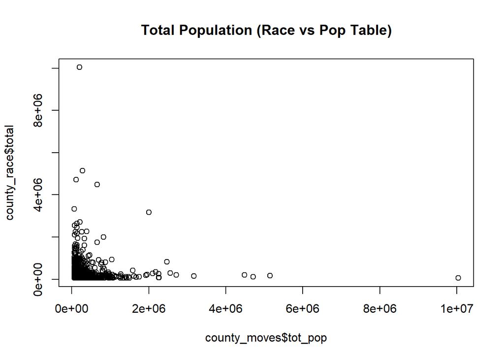

```r
plot(county_moves$tot_pop, county_race$total, main = "Total Population (Race vs Pop Table)")
```

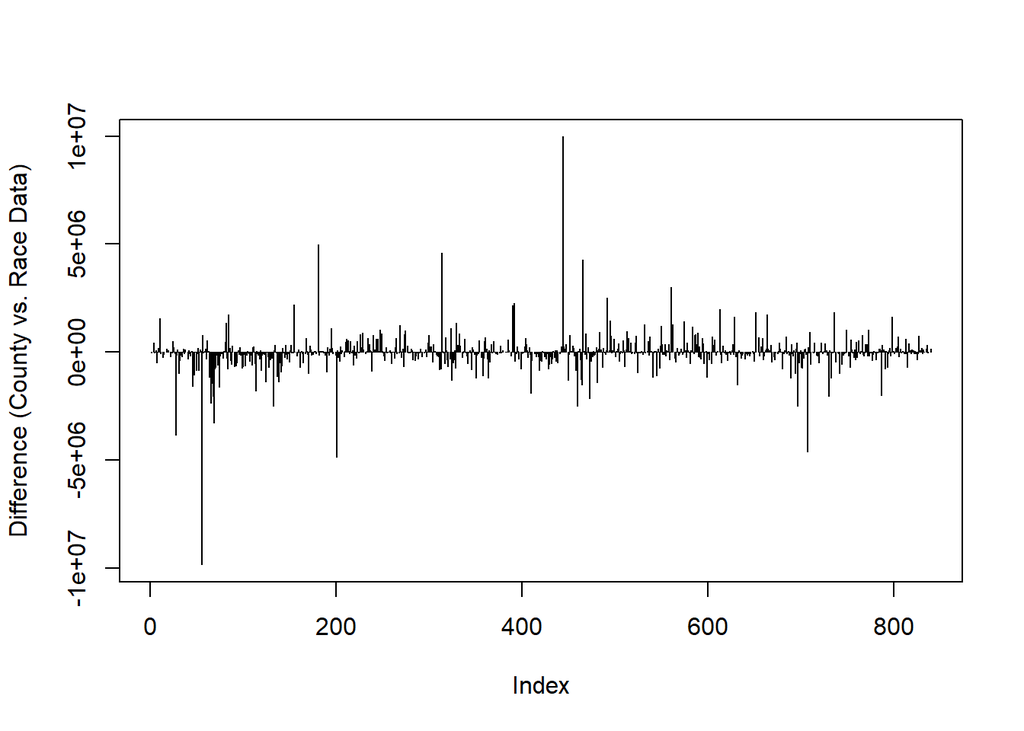

```r
# seems like there are some discrepancies...
plot(county_moves$tot_pop - county_race$total, type='h', ylab = "Difference (County vs. Race Data)")
```

```r
## most have small differences... will just go with the county population data rather than the race. likely more standardized

# join move data with race data and get rid of county 1 (King County)
county_race_moves <- merge(county_moves, county_race, by.x="county2", by.y = "county_name", all.x=TRUE) %>%
  select(-c(total, county1))

head(county_race_moves)
```

```
## Simple feature collection with 6 features and 12 fields (with 3 geometries empty)
## Geometry type: GEOMETRY
## Dimension:     XY
## Bounding box:  xmin: -121.8358 ymin: 47.49084 xmax: -121.8358 ymax: 47.49084
## Geodetic CRS:  NAD83
##                              county2 movers tot_pop white_alone black_alone
## 1 Mayag\xfcez Municipio, Puerto Rico      0   71530       25994        1959
## 2     Do\xf1a Ana County, New Mexico      0  218195      174131        3881
## 3  Bayam\xf3n Municipio, Puerto Rico      0  169269      114990       14813
## 4                  Ada County, Idaho    335  481587      434358        6795
## 5             Adams County, Colorado     19  517421      410925       18728
## 6             Adams County, Illinois     18   65435          NA          NA
##   amer_ind_ak_alone asian_alone nat_haw_pac_alone other_alone two_plus_alone
## 1                 0          27                 0       42915            635
## 2              2930        3135               229       29566           4323
## 3               296         307                 0       10739          28124
## 4              3848       11196               655        7446          17289
## 5              4884       20608               692       33151          28433
## 6                NA          NA                NA          NA             NA
##   two_some_other two_ex_some_three_plus                   geometry
## 1            448                    187   GEOMETRYCOLLECTION EMPTY
## 2            813                   3510   GEOMETRYCOLLECTION EMPTY
## 3            809                  27315   GEOMETRYCOLLECTION EMPTY
## 4            502                  16787 POINT (-121.8358 47.49084)
## 5           4359                  24074 POINT (-121.8358 47.49084)
## 6             NA                     NA POINT (-121.8358 47.49084)
```

```r
# change the weird string stuff
county_race_moves$county2 <- iconv(county_race_moves$county2, "UTF-8", "ASCII", sub = "")
```

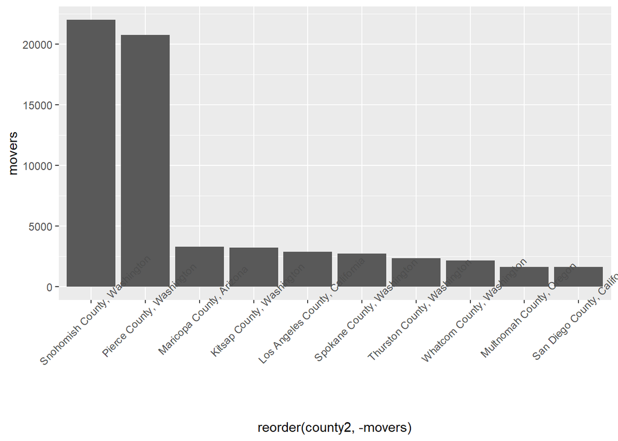

```r
# which counties saw most people moving from King County?
# top 10
top_10 <- county_race_moves %>%
  arrange(desc(movers)) %>%
  slice(1:10)

ggplot(data = top_10, mapping = aes(x = reorder(county2, -movers), y = movers)) +
  geom_col(stat = "identity") +
  theme(axis.text.x = element_text(angle=45, vjust = 1))
```

Lots of movers to nearby counties. Makes sense.

### Trying out more tidycensus functions

```r
#test <- get_pums(variables = "NP", year = 2019, state = "WA", survey = "acs1", recode = TRUE)

race_vars <- c(
  Hispanic = "P2_002N",
  White = "P2_005N",
  Black = "P2_006N",
  Asian = "P2_008N"
)

sea_race <- get_decennial(
  geography = "tract",
  variables = race_vars,
  state = "WA",
  county = "King County",
  geometry = TRUE,
  year = 2020
)
```

```
## Using the PL 94-171 Redistricting Data Summary File
```

```
## Note: 2020 decennial Census data use differential privacy, a technique that
## introduces errors into data to preserve respondent confidentiality.
## ℹ Small counts should be interpreted with caution.
## ℹ See https://www.census.gov/library/fact-sheets/2021/protecting-the-confidentiality-of-the-2020-census-redistricting-data.html for additional guidance.
```

```r
sea_dots <- as_dot_density(
  sea_race,
  value = "value",
  values_per_dot = 100,
  group = "variable"
)

sea_base <- sea_race[sea_race$variable == "Hispanic",]

ggplot() +
  geom_sf(data = sea_base,
          fill = 'white',
          color = 'grey') +
  geom_sf(data = sea_dots,
          aes(color = variable),
          size = 1) +
  theme_void()
# define a function to gather median income, other socioeconomic data
#create_socioecon_data <- function(year) {

#}

# test2 <- get_flows(geography = "county subdivision",
#                            state="WA",
#                            #county="King County",
#                            year = 2020,
#                            geometry = TRUE)
```

[output not shown]

```r
sea_flows_2015 <- get_flows(
  geography = "metropolitan statistical area",
  breakdown = "RACE",
  breakdown_labels = TRUE,
  msa = 42660,
  year = 2015,
  geometry = TRUE
)

sea_flows_2020 <- get_flows(
  geography = "metropolitan statistical area",
  breakdown_labels = TRUE,
  msa = 42660,
  year = 2020,
  geometry = TRUE
)

head(sea_flows_2015)
```

```
## Simple feature collection with 6 features and 9 fields
## Active geometry column: centroid1
## Geometry type: POINT
## Dimension:     XY
## Bounding box:  xmin: -121.8814 ymin: 47.5574 xmax: -121.8814 ymax: 47.5574
## Geodetic CRS:  NAD83
## # A tibble: 6 × 11
##   GEOID1 GEOID2 FULL1_NAME   FULL2_NAME RACE  RACE_label variable estimate   moe
##   <chr>  <chr>  <chr>        <chr>      <chr> <chr>      <chr>       <dbl> <dbl>
## 1 42660  <NA>   Seattle-Tac… Outside M… 00    All races  MOVEDIN     20259  1505
## 2 42660  <NA>   Seattle-Tac… Outside M… 00    All races  MOVEDOUT    24721  1676
## 3 42660  <NA>   Seattle-Tac… Outside M… 00    All races  MOVEDNET    -4462  2193
## 4 42660  <NA>   Seattle-Tac… Africa     00    All races  MOVEDIN      3082   821
## 5 42660  <NA>   Seattle-Tac… Africa     00    All races  MOVEDOUT       NA    NA
## 6 42660  <NA>   Seattle-Tac… Africa     00    All races  MOVEDNET       NA    NA
## # ℹ 2 more variables: centroid1 <POINT [°]>, centroid2 <POINT [°]>
```

```r
head(sea_flows_2020)
```

```
## Simple feature collection with 6 features and 7 fields
## Active geometry column: centroid1
## Geometry type: POINT
## Dimension:     XY
## Bounding box:  xmin: -121.8814 ymin: 47.5574 xmax: -121.8814 ymax: 47.5574
## Geodetic CRS:  NAD83
## # A tibble: 6 × 9
##   GEOID1 GEOID2 FULL1_NAME                    FULL2_NAME variable estimate   moe
##   <chr>  <chr>  <chr>                         <chr>      <chr>       <dbl> <dbl>
## 1 42660  <NA>   Seattle-Tacoma-Bellevue, WA … Outside M… MOVEDIN     17039  1376
## 2 42660  <NA>   Seattle-Tacoma-Bellevue, WA … Outside M… MOVEDOUT    25243  1528
## 3 42660  <NA>   Seattle-Tacoma-Bellevue, WA … Outside M… MOVEDNET    -8204  2128
## 4 42660  <NA>   Seattle-Tacoma-Bellevue, WA … Africa     MOVEDIN      2545   601
## 5 42660  <NA>   Seattle-Tacoma-Bellevue, WA … Africa     MOVEDOUT       NA    NA
## 6 42660  <NA>   Seattle-Tacoma-Bellevue, WA … Africa     MOVEDNET       NA    NA
## # ℹ 2 more variables: centroid1 <POINT [°]>, centroid2 <POINT [°]>
```

### Trying out mapdeck/mapbox

```r
set_token("pk.eyJ1IjoibWFsaWFqYyIsImEiOiJjazNxYzBkZXgwMDMwM2VxdXZtanZwM2t3In0.It8ATez8CuG6PlSeu9-SUQ")

# try out mapdeck
## data wrangling
top_move_out <- sea_flows_2015 %>%
  filter(!is.na(GEOID2), variable == "MOVEDOUT") %>%
  slice_max(n = 25, order_by = estimate) %>%
  mutate(
    width = estimate / 500,
    tooltip = paste0(
      scales::comma(estimate * 5, 1),
      " people moved from ", str_remove(FULL1_NAME, "Metro Area"),
      " to ", str_remove(FULL2_NAME, "Metro Area"), " between 2011 and 2015"
    )
  )

# map the top 25 MSAs moving out from WA
top_move_out %>%
  mapdeck(style=mapdeck_style("dark"), pitch = 45) %>%
  add_arc(
    origin = "centroid1",
    destination = "centroid2",
    stroke_width = "width",
    auto_highlight = TRUE,
    highlight_colour = "#8c43facc",
    tooltip = "tooltip"
  ) %>%
  add_title(title = list(title = "Top 25 Destinations from SEA-TAC-BELL Metropolitan Statistical Areas (2011 - 2015)",
            css = "color: black;"))
```

[interactive chart not shown]

```r
top_move_out <- sea_flows_2020 %>%
  filter(!is.na(GEOID2), variable == "MOVEDOUT") %>%
  slice_max(n = 25, order_by = estimate) %>%
  mutate(
    width = estimate / 500,
    tooltip = paste0(
      scales::comma(estimate * 5, 1),
      " people moved from ", str_remove(FULL1_NAME, "Metro Area"),
      " to ", str_remove(FULL2_NAME, "Metro Area"), " between 2016 and 2020"
    )
  )

# map the top 25 MSAs moving out from WA
top_move_out %>%
  mapdeck(style=mapdeck_style("dark"), pitch = 45) %>%
  add_arc(
    origin = "centroid1",
    destination = "centroid2",
    stroke_width = "width",
    auto_highlight = TRUE,
    highlight_colour = "#8c43facc",
    tooltip = "tooltip"
  ) %>%
  add_title(title = list(title = "Top 25 Destinations from SEA-TAC-BELL Metropolitan Statistical Areas (2016 - 2020)",
            css = "color: black;"))
```

[interactive chart not shown]

Much more widespread migration patterns from 2015 to 2020.

```r
# calculate race percentages and supplement data
# remove "conflicting" race categories
county_race[is.na(county_race$total),]
```

```
##                           county_name total white_alone black_alone
## 3             Cullman County, Alabama    NA          NA          NA
## 16             Morgan County, Alabama    NA          NA          NA
## 17          St. Clair County, Alabama    NA          NA          NA
## 21             Walker County, Alabama    NA          NA          NA
## 39         Jefferson County, Arkansas    NA          NA          NA
## 40            Lonoke County, Arkansas    NA          NA          NA
## 157           Catoosa County, Georgia    NA          NA          NA
## 166         Dougherty County, Georgia    NA          NA          NA
## 180            Newton County, Georgia    NA          NA          NA
## 184          Spalding County, Georgia    NA          NA          NA
## 198          Twin Falls County, Idaho    NA          NA          NA
## 199            Adams County, Illinois    NA          NA          NA
## 224             Boone County, Indiana    NA          NA          NA
## 231           Hancock County, Indiana    NA          NA          NA
```

[output cut: 165 more lines]

```r
# input ACS characteristics for missing counties
# exclude the categories that feed into "two plus"
county_race_moves <- county_race_moves %>%
  select(-c(two_some_other, two_ex_some_three_plus))

# test this out
race_test <- get_acs(geography = "county", variables = c("B02001_001", "B02001_002", "B02001_003", "B02001_004", "B02001_005", "B02001_006", "B02001_007", "B02001_008"), year = 2019, output="wide") %>%
    # exclude MOE estimates
    select(-c(B02001_001M, B02001_002M, B02001_003M, B02001_004M, B02001_005M, B02001_006M, B02001_007M, B02001_008M))
sum(is.na(race_test$B02001_003E))
```

```
## [1] 0
```

### Trying out ipumsr package functions with tidycensus

```r
median_hou_msa_2019 <- read_nhgis("data/nhgis0004_csv/nhgis0004_ds243_2019_metdiv.csv")
```

```
## Use of data from NHGIS is subject to conditions including that users should cite the data appropriately. Use command `ipums_conditions()` for more details.
```

```r
head(median_hou_msa_2019)
```

```
## # A tibble: 6 × 31
##   GISJOIN    YEAR STUSAB REGIONA DIVISIONA STATEA COUNTYA COUSUBA PLACEA AIANHHA
##   <chr>     <dbl> <chr>  <lgl>   <lgl>     <lgl>  <lgl>   <lgl>   <lgl>  <lgl>
## 1 G1446014…  2019 US     NA      NA        NA     NA      NA      NA     NA
## 2 G1446015…  2019 US     NA      NA        NA     NA      NA      NA     NA
## 3 G1446040…  2019 US     NA      NA        NA     NA      NA      NA     NA
## 4 G1698016…  2019 US     NA      NA        NA     NA      NA      NA     NA
## 5 G1698020…  2019 US     NA      NA        NA     NA      NA      NA     NA
## 6 G1698023…  2019 US     NA      NA        NA     NA      NA      NA     NA
## # ℹ 21 more variables: ANRCA <lgl>, CBSA <chr>, CBSAA <dbl>, CSAA <lgl>,
## #   METDIV <chr>, METDIVA <dbl>, NECTAA <lgl>, CNECTAA <lgl>, NECTADIVA <lgl>,
## #   UAA <lgl>, CDCURRA <lgl>, SDELMA <lgl>, SDSECA <lgl>, SDUNIA <lgl>,
## #   PCI <lgl>, PUMAA <lgl>, GEOID <chr>, NAME_E <chr>, ALLJE001 <dbl>,
## #   NAME_M <chr>, ALLJM001 <dbl>
```

```r
mig <- get_flows(
  geography = "metropolitan statistical area",
  breakdown_labels = TRUE,
  msa = 42660,
  year = 2019,
  geometry = TRUE
)

head(mig)
```

```
## Simple feature collection with 6 features and 7 fields
## Active geometry column: centroid1
## Geometry type: POINT
## Dimension:     XY
## Bounding box:  xmin: -121.8814 ymin: 47.5574 xmax: -121.8814 ymax: 47.5574
## Geodetic CRS:  NAD83
## # A tibble: 6 × 9
##   GEOID1 GEOID2 FULL1_NAME                    FULL2_NAME variable estimate   moe
##   <chr>  <chr>  <chr>                         <chr>      <chr>       <dbl> <dbl>
## 1 42660  <NA>   Seattle-Tacoma-Bellevue, WA … Outside M… MOVEDIN     17497  1391
## 2 42660  <NA>   Seattle-Tacoma-Bellevue, WA … Outside M… MOVEDOUT    26004  1640
## 3 42660  <NA>   Seattle-Tacoma-Bellevue, WA … Outside M… MOVEDNET    -8507  2099
## 4 42660  <NA>   Seattle-Tacoma-Bellevue, WA … Africa     MOVEDIN      3126   582
## 5 42660  <NA>   Seattle-Tacoma-Bellevue, WA … Africa     MOVEDOUT       NA    NA
## 6 42660  <NA>   Seattle-Tacoma-Bellevue, WA … Africa     MOVEDNET       NA    NA
## # ℹ 2 more variables: centroid1 <POINT [°]>, centroid2 <POINT [°]>
```

```r
sea_tac_bell_flows <- mig %>%
  select(-moe) %>%
  filter(FULL1_NAME == "Seattle-Tacoma-Bellevue, WA Metro Area")

head(sea_tac_bell_flows)
```

```
## Simple feature collection with 6 features and 6 fields
## Active geometry column: centroid1
## Geometry type: POINT
## Dimension:     XY
## Bounding box:  xmin: -121.8814 ymin: 47.5574 xmax: -121.8814 ymax: 47.5574
## Geodetic CRS:  NAD83
## # A tibble: 6 × 8
##   GEOID1 GEOID2 FULL1_NAME                          FULL2_NAME variable estimate
##   <chr>  <chr>  <chr>                               <chr>      <chr>       <dbl>
## 1 42660  <NA>   Seattle-Tacoma-Bellevue, WA Metro … Outside M… MOVEDIN     17497
## 2 42660  <NA>   Seattle-Tacoma-Bellevue, WA Metro … Outside M… MOVEDOUT    26004
## 3 42660  <NA>   Seattle-Tacoma-Bellevue, WA Metro … Outside M… MOVEDNET    -8507
## 4 42660  <NA>   Seattle-Tacoma-Bellevue, WA Metro … Africa     MOVEDIN      3126
## 5 42660  <NA>   Seattle-Tacoma-Bellevue, WA Metro … Africa     MOVEDOUT       NA
## 6 42660  <NA>   Seattle-Tacoma-Bellevue, WA Metro … Africa     MOVEDNET       NA
## # ℹ 2 more variables: centroid1 <POINT [°]>, centroid2 <POINT [°]>
```

```r
# load in time series data for race (1990, 2000, 2010, 2020)
race_change_1990_2020_cbsa <- read_nhgis("data/nhgis0005_csv/nhgis0005_csv/nhgis0005_ts_geog2010_cbsa.csv")
```

```
## Use of data from NHGIS is subject to conditions including that users should cite the data appropriately. Use command `ipums_conditions()` for more details.
```

```r
head(race_change_1990_2020_cbsa)
```

```
## # A tibble: 6 × 72
##   GISJOIN GEOGYEAR CBSA          CBSAA CM1AA1990 CM1AA1990L CM1AA1990U CM1AA2000
##   <chr>      <dbl> <chr>         <dbl>     <dbl>      <dbl>      <dbl>     <dbl>
## 1 G10020      2010 Abbeville, L… 10020    42320.      42237      43225    44598.
## 2 G10100      2010 Aberdeen, SD… 10100    38711.      38702      38740    38186.
## 3 G10140      2010 Aberdeen, WA… 10140    60230.      60003      60249    59335.
## 4 G10180      2010 Abilene, TX … 10180   125505.     125416     125561   130625.
## 5 G10220      2010 Ada, OK Micr… 10220    28246.      28143      28374    26638.
## 6 G10300      2010 Adrian, MI M… 10300    86323       86323      86323    91484
## # ℹ 64 more variables: CM1AA2000L <dbl>, CM1AA2000U <dbl>, CM1AA2010 <dbl>,
## #   CM1AA2020 <dbl>, CM1AA2020L <dbl>, CM1AA2020U <dbl>, CM1AB1990 <dbl>,
## #   CM1AB1990L <dbl>, CM1AB1990U <dbl>, CM1AB2000 <dbl>, CM1AB2000L <dbl>,
## #   CM1AB2000U <dbl>, CM1AB2010 <dbl>, CM1AB2020 <dbl>, CM1AB2020L <dbl>,
## #   CM1AB2020U <dbl>, CM1AC1990 <dbl>, CM1AC1990L <dbl>, CM1AC1990U <dbl>,
## #   CM1AC2000 <dbl>, CM1AC2000L <dbl>, CM1AC2000U <dbl>, CM1AC2010 <dbl>,
## #   CM1AC2020 <dbl>, CM1AC2020L <dbl>, CM1AC2020U <dbl>, CM1AD1990 <dbl>, …
```

```r
# TODO: CREATE FUNCTION FOR THIS PROCESS
# movers by race
movers_by_race_2015 <- sea_flows_2015 %>%
  filter(variable == "MOVEDOUT") %>%
  filter(RACE_label != "All races") %>%
  select(c(RACE_label, variable, estimate))

head(movers_by_race_2015)
```

```
## Simple feature collection with 6 features and 3 fields
## Geometry type: POINT
## Dimension:     XY
## Bounding box:  xmin: -121.8814 ymin: 47.5574 xmax: -121.8814 ymax: 47.5574
## Geodetic CRS:  NAD83
## # A tibble: 6 × 4
##   RACE_label  variable estimate           centroid1
##   <chr>       <chr>       <dbl>         <POINT [°]>
## 1 White alone MOVEDOUT    20092 (-121.8814 47.5574)
## 2 White alone MOVEDOUT       NA (-121.8814 47.5574)
## 3 White alone MOVEDOUT       NA (-121.8814 47.5574)
## 4 White alone MOVEDOUT       NA (-121.8814 47.5574)
## 5 White alone MOVEDOUT       NA (-121.8814 47.5574)
## 6 White alone MOVEDOUT       NA (-121.8814 47.5574)
```

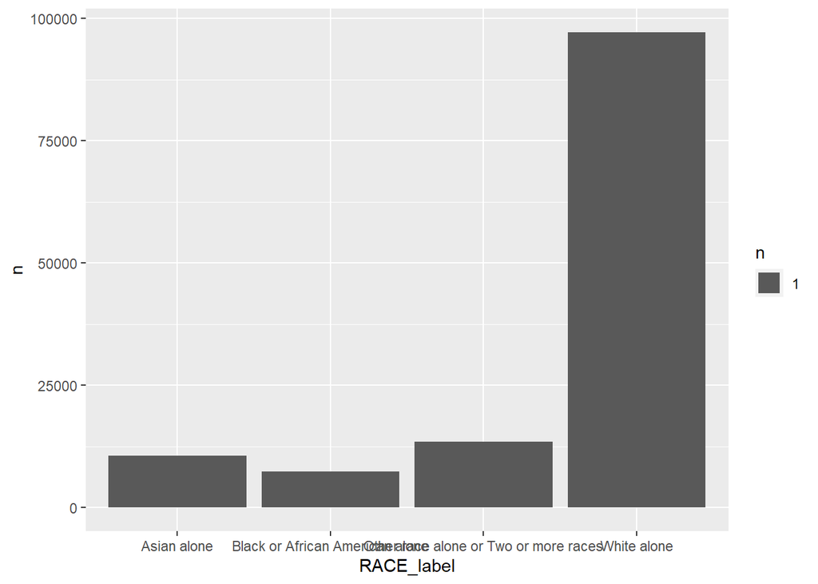

```r
total_movers_race <- movers_by_race_2015 %>%
  group_by(RACE_label) %>%
  summarize(n = sum(estimate, na.rm = TRUE))

ggplot(data = total_movers_race, mapping = aes(x = RACE_label, y = n)) +
  geom_histogram(na.rm = TRUE, stat = "sum")
```

```r
# B02001_002: White alone
# B02001_003: Black or African American alone
# B02001_005: Asian alone
# B02001_009: Two or more and other
# TODO: percent movers by race
data <- get_acs(year = 2015, variables = c("B02001_002", "B02001_003", "B02001_005", "B02001_009"), geography = "metropolitan statistical area/micropolitan statistical area")
total_pops_2015 <- data %>%
  filter(NAME == "Seattle-Tacoma-Bellevue, WA Metro Area")

total_pops_2015 <- total_pops_2015 %>% mutate(
  race = case_when(
    variable == "B02001_002" ~ "White alone",
    variable == "B02001_003" ~ "Black or African American alone",
    variable == "B02001_005" ~ "Asian alone",
    variable == "B02001_009" ~ "Other race alone or Two or more races",
    .default = "other"
))

head(total_pops_2015)
```

```
## # A tibble: 4 × 6
##   GEOID NAME                                   variable   estimate   moe race
##   <chr> <chr>                                  <chr>         <dbl> <dbl> <chr>
## 1 42660 Seattle-Tacoma-Bellevue, WA Metro Area B02001_002  2595362  4927 White …
## 2 42660 Seattle-Tacoma-Bellevue, WA Metro Area B02001_003   201348  2622 Black …
## 3 42660 Seattle-Tacoma-Bellevue, WA Metro Area B02001_005   439338  2806 Asian …
## 4 42660 Seattle-Tacoma-Bellevue, WA Metro Area B02001_009    18151  1577 Other …
```

```r
# join pops and movers
pops_movers_2015 <- merge(total_pops_2015, total_movers_race, by.x = "race", by.y = "RACE_label") %>%
  select(-variable)

head(pops_movers_2015)
```

```
##                                    race GEOID
## 1                           Asian alone 42660
## 2       Black or African American alone 42660
## 3 Other race alone or Two or more races 42660
## 4                           White alone 42660
##                                     NAME estimate  moe     n
## 1 Seattle-Tacoma-Bellevue, WA Metro Area   439338 2806 10572
## 2 Seattle-Tacoma-Bellevue, WA Metro Area   201348 2622  7399
## 3 Seattle-Tacoma-Bellevue, WA Metro Area    18151 1577 13522
## 4 Seattle-Tacoma-Bellevue, WA Metro Area  2595362 4927 97120
##                   centroid1
## 1 POINT (-121.8814 47.5574)
## 2 POINT (-121.8814 47.5574)
## 3 POINT (-121.8814 47.5574)
## 4 POINT (-121.8814 47.5574)
```

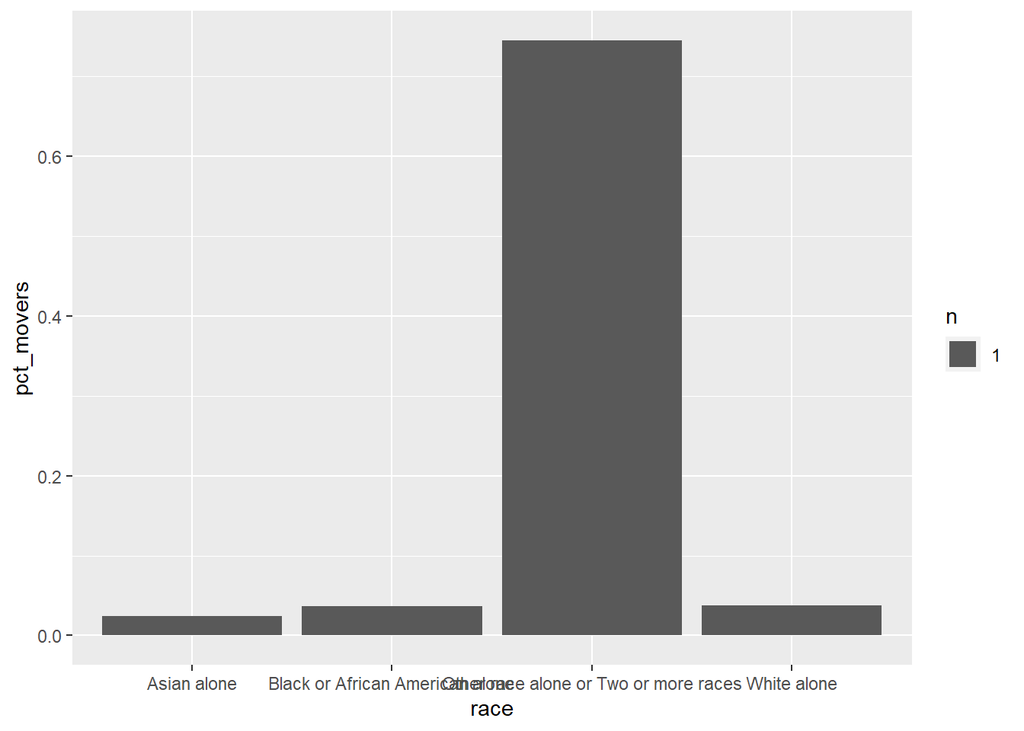

```r
pops_movers_2015$pct_movers <- pops_movers_2015$n / pops_movers_2015$estimate

ggplot(data = pops_movers_2015, mapping = aes(x = race, y = pct_movers)) +
  geom_histogram(na.rm = TRUE, stat = "sum")
```

While there are more white movers (way outnumber other classes), the percent of people in the “two or more/other” category that are moving out of Seattle-Tacoma-Bellevue vastly outnumbers the other race categories.

## Functions

```r
# define functions to clean and join data given year
# TODO: MODIFY TO INCLUDE MULTIPLE YEARS WITH RBIND
create_county_flows <- function(year) {
  # load flows for WA King County
  king_county_flows <- get_flows(geography = "county",
                           state="WA",
                           county="King",
                           year = year,
                           geometry = TRUE)

  # filter for just movers out of KC
  king_county_flows <- king_county_flows %>%
    filter(variable == "MOVEDOUT") %>%
    select(-c(moe, FULL1_NAME, variable))

  # rename migration columns
  setnames(king_county_flows,
           old=c("FULL2_NAME", "estimate"),
           new=c("county_name", "movers"))

  # call for race data up to "two or more"
  county_races <- get_acs(geography = "county", variables = c("B02001_001", "B02001_002", "B02001_003", "B02001_004", "B02001_005", "B02001_006", "B02001_007", "B02001_008"),
                          year = year, output="wide") %>%
    # exclude MOE estimates
    select(-c(B02001_001M, B02001_002M, B02001_003M, B02001_004M, B02001_005M, B02001_006M, B02001_007M, B02001_008M))

  # rename race columns
  setnames(county_races,
           old=c("NAME", "B02001_001E", "B02001_002E", "B02001_003E", "B02001_004E", "B02001_005E", "B02001_006E", "B02001_007E", "B02001_008E"),
           new=c("county_name", "total_pop", "white_alone", "black_alone", "amer_ind_ak_alone", "asian_alone", "nat_haw_pac_alone", "other_alone", "two_plus"))

  king_county_comp <- merge(king_county_flows, county_races, by = "county_name", all.y=TRUE) %>%
    select(-c(GEOID1, GEOID2, centroid2)) %>%
    data.frame()

  king_county_comp[is.na(king_county_comp)] <- 0
  return(king_county_comp)
}
```

```r
# define a function to calculate percentages of each race given dataset
calc_percentages <- function(data){
  race_cols <- c("white_alone", "black_alone", "amer_ind_ak_alone", "asian_alone", "nat_haw_pac_alone", "other_alone", "two_plus")

  for (race in race_cols) {
    data[[race]] <- (data[[race]] / data$total_pop) * 100
  }

  return(data)
}
```

```r
# define a function to calculate percent difference between KC and other counties
calc_differences <- function(data) {
  race_cols <- c("white_alone", "black_alone", "amer_ind_ak_alone", "asian_alone", "nat_haw_pac_alone", "other_alone", "two_plus")

  kc <- data[data$county_name == "King County, Washington",]

  # get differences between king county and column
  pct_diff <- lapply(race_cols, function(race) {
    data[[race]] - kc[[race]]
  })

  # convert to a dataframe
  pct_diff_df <- as.data.frame(pct_diff)

  # rename cols
  colnames(pct_diff_df) <- paste0("diff_pct_", race_cols)

  # bind percentage differences
  data <- cbind(data, pct_diff_df)

  return(data)
}
```

```r
# yay!
dat.2019 <- create_county_flows(2019)
pct.2019 <- calc_percentages(dat.2019)

# yay!
# differences calculated by King County - each county
diffs <- calc_differences(pct.2019)
```

## Tests

```r
# relationship between race and whether someone has moved?
# try for 2015
# contingency table
head(sea_flows_2015)
```

```
## Simple feature collection with 6 features and 9 fields
## Active geometry column: centroid1
## Geometry type: POINT
## Dimension:     XY
## Bounding box:  xmin: -121.8814 ymin: 47.5574 xmax: -121.8814 ymax: 47.5574
## Geodetic CRS:  NAD83
## # A tibble: 6 × 11
##   GEOID1 GEOID2 FULL1_NAME   FULL2_NAME RACE  RACE_label variable estimate   moe
##   <chr>  <chr>  <chr>        <chr>      <chr> <chr>      <chr>       <dbl> <dbl>
## 1 42660  <NA>   Seattle-Tac… Outside M… 00    All races  MOVEDIN     20259  1505
## 2 42660  <NA>   Seattle-Tac… Outside M… 00    All races  MOVEDOUT    24721  1676
## 3 42660  <NA>   Seattle-Tac… Outside M… 00    All races  MOVEDNET    -4462  2193
## 4 42660  <NA>   Seattle-Tac… Africa     00    All races  MOVEDIN      3082   821
## 5 42660  <NA>   Seattle-Tac… Africa     00    All races  MOVEDOUT       NA    NA
## 6 42660  <NA>   Seattle-Tac… Africa     00    All races  MOVEDNET       NA    NA
## # ℹ 2 more variables: centroid1 <POINT [°]>, centroid2 <POINT [°]>
```

```r
cont.race <- data.frame(
  "Race" = c("Black", "Non-black"),
  "Moved" = c("Yes", "No")
)
```

## Models

### Tree (Raw Percentages)

```r
# exclude KC
pct.2019 <- pct.2019 %>%
  select(-c(GEOID, centroid2)) %>%
  filter(county_name != "King County, Washington")
```

```r
set.seed(2)

# select variables for analysis
data <- pct.2019 %>%
  select(c(county_name, movers, white_alone, black_alone, amer_ind_ak_alone, asian_alone, nat_haw_pac_alone, other_alone, two_plus))

# model data
mod1.data <- data %>%
  select(c(movers, white_alone, black_alone, amer_ind_ak_alone, asian_alone, nat_haw_pac_alone, other_alone, two_plus))

train <- sample(1:nrow(mod1.data), nrow(mod1.data) * 0.8)

pcts.train <- mod1.data[train,]
pcts.test <- mod1.data[-train,]

tree.pcts <- tree(movers ~ ., data=pcts.train)
summary(tree.pcts)
```

```
##
## Regression tree:
## tree(formula = movers ~ ., data = pcts.train)
## Variables actually used in tree construction:
## [1] "nat_haw_pac_alone" "asian_alone"       "black_alone"
## Number of terminal nodes:  5
## Residual mean deviance:  151200 = 388600000 / 2570
## Distribution of residuals:
##     Min.  1st Qu.   Median     Mean  3rd Qu.     Max.
## -4247.00   -10.43   -10.43     0.00   -10.43 16490.00
```

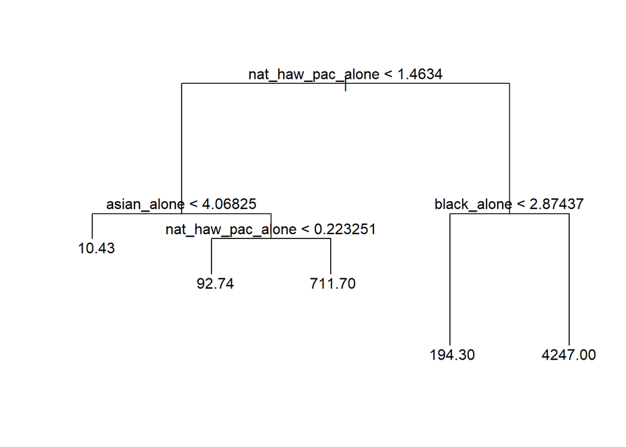

```r
plot(tree.pcts)
text(tree.pcts, pretty = 0)
```

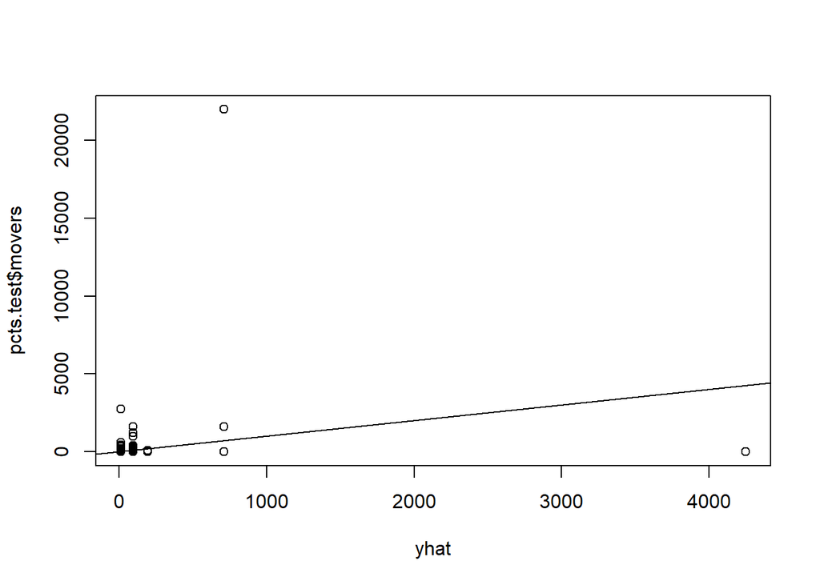

```r
# predict on test set
yhat <- predict(tree.pcts, newdata=pcts.test)

plot(yhat, pcts.test$movers)
abline(0, 1)
```

```r
# lmaooo
mean((yhat - pcts.test$movers)^2)
```

```
## [1] 755145.1
```

```r
sqrt(mean((yhat - pcts.test$movers)^2))
```

```
## [1] 868.9909
```